# 2000 Election Prediction Model

Kat Devlin

2017年9月22日

Bush vs Buchanan: Google “butterfly ballot” if not already familiar.

```r
x <- read.csv("BushBuchananElection2000.csv", as.is=TRUE)
head(x)
```

```
##     county buchanan2000 bush2000
## 1  ALACHUA          262    34062
## 2    BAKER           73     5610
## 3      BAY          248    38637
## 4 BRADFORD           65     5413
## 5  BREVARD          570   115185
## 6  BROWARD          789   177279
```

```r
tail(x)
```

```
##        county buchanan2000 bush2000
## 62      UNION           26     2326
## 63    VOLUSIA          396    82214
## 64    WAKULLA           46     4511
## 65     WALTON          120    12176
## 66 WASHINGTON           88     4983
## 67 PALM BEACH         3407   152846
```

```r
pb <- x[x$county=="PALM BEACH",]
y <- x[x$county!="PALM BEACH",]
```

Using `x`, here is a scatterplot with votes for Buchanan on the y-axis and votes for Bush on the x-axis. Using text() I’ve labeled the point for Palm Beach County. The idea is that in Palm Beach the number of votes for Buchanan was surprisingly high; could be that many were intended for Gore but the butterfly ballot confused voters. Here, I’ll try to use support for Bush to predict votes for Buchanan in Palm Beach.

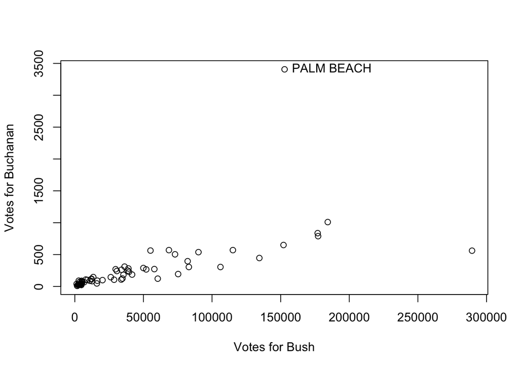

Now using `y`, I explore log() and sqrt() transformations of the variables that make the association close to linear with roughly constant variance around the general trend.

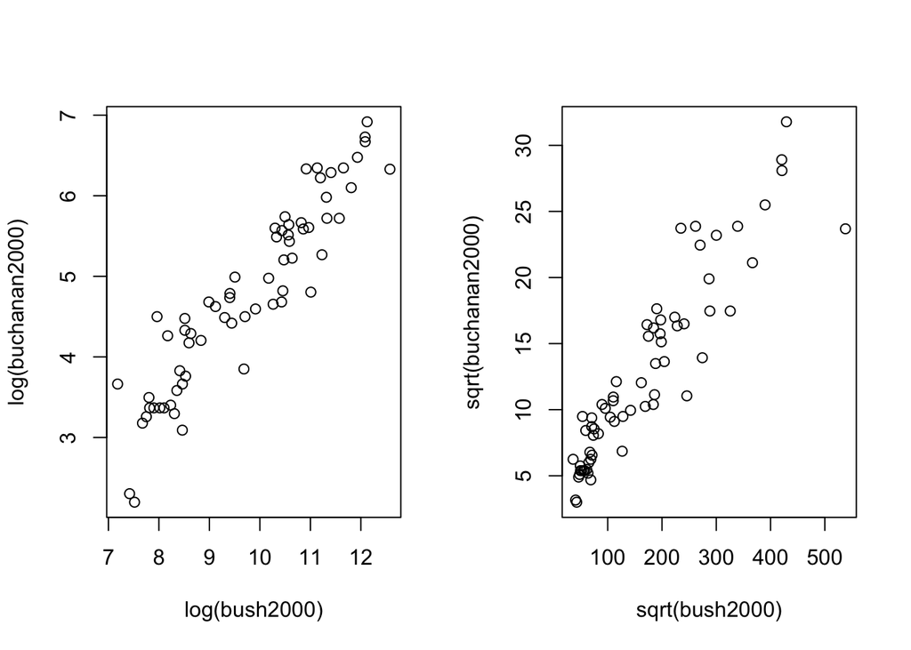

Next I fit a linear model complete with scatterplot of the transformed variables and superimposed regression line.

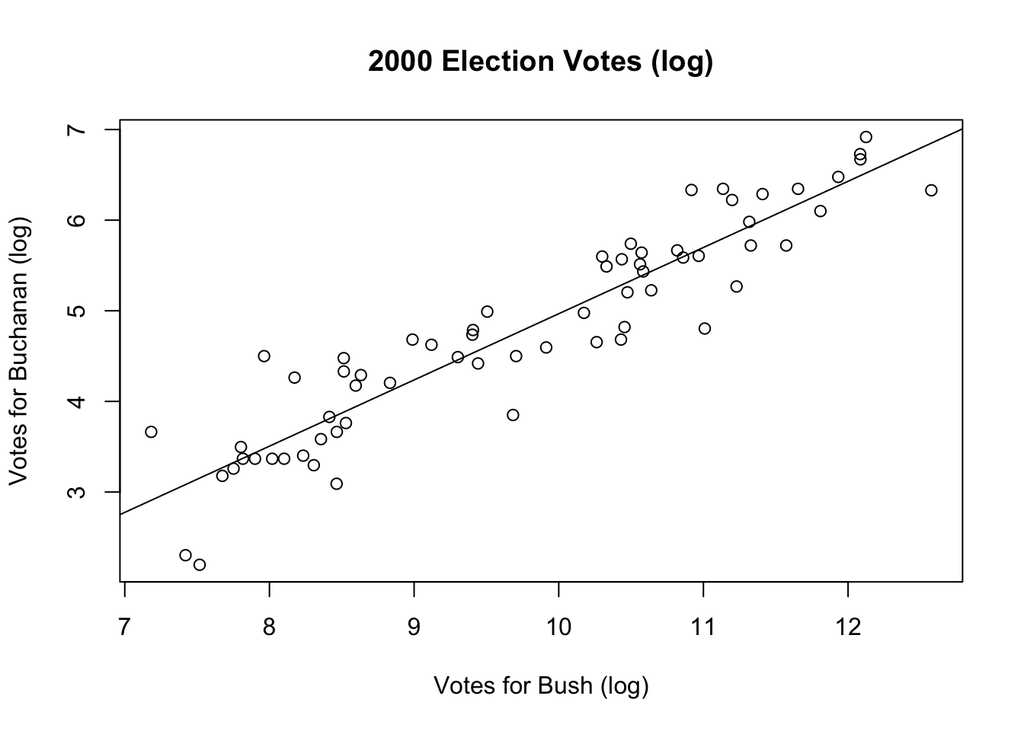

```
##
## Call:
## lm(formula = log(buchanan2000) ~ log(bush2000), data = y)
##
## Residuals:
##      Min       1Q   Median       3Q      Max
## -0.95631 -0.21236  0.02503  0.28102  1.02056
##
## Coefficients:
##               Estimate Std. Error t value Pr(>|t|)
## (Intercept)   -2.34149    0.35442  -6.607 9.07e-09 ***
## log(bush2000)  0.73096    0.03597  20.323  < 2e-16 ***
## ---
## Signif. codes:  0 '***' 0.001 '**' 0.01 '*' 0.05 '.' 0.1 ' ' 1
##
## Residual standard error: 0.4198 on 64 degrees of freedom
## Multiple R-squared:  0.8658, Adjusted R-squared:  0.8637
## F-statistic:   413 on 1 and 64 DF,  p-value: < 2.2e-16
```

This has a high R^2 (0.8658) and low residual std error (0.4198), meaning that the model fits the data well. Unsure if it fits so well as to appear slightly unreasonable. But good fit nonetheless.

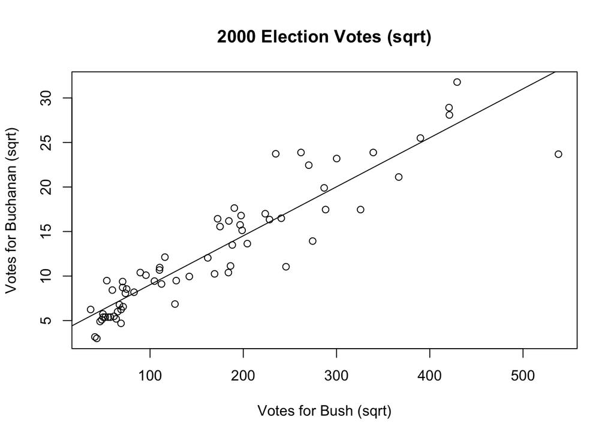

```
##
## Call:
## lm(formula = sqrt(buchanan2000) ~ sqrt(bush2000), data = y)
##
## Residuals:
##     Min      1Q  Median      3Q     Max
## -9.4318 -1.2646 -0.0807  1.5764  7.2903
##
## Coefficients:
##                Estimate Std. Error t value Pr(>|t|)
## (Intercept)     3.51995    0.59009   5.965 1.16e-07 ***
## sqrt(bush2000)  0.05501    0.00289  19.037  < 2e-16 ***
## ---
## Signif. codes:  0 '***' 0.001 '**' 0.01 '*' 0.05 '.' 0.1 ' ' 1
##
## Residual standard error: 2.739 on 64 degrees of freedom
## Multiple R-squared:  0.8499, Adjusted R-squared:  0.8476
## F-statistic: 362.4 on 1 and 64 DF,  p-value: < 2.2e-16
```

The square root model also has a high R^2 (0.8499) and not quite as low resid std error (2.739), but still strong fit.

Now that we’ve fitted the model, I use predict() to predict votes for Buchanan, with `newdata=pb` as an option. I want to compare this prediction to the actual votes for Buchanan in Palm Beach, 3407.

```r
pb$logpat2000 <- log(pb$buchanan2000)
pb$logw2000 <- log(pb$bush2000)
pb$sqrtpat2000 <- sqrt(pb$buchanan2000)
pb$sqrtw2000 <- sqrt(pb$bush2000)

exp(predict(lm.test1, newdata=pb)) # ~592 votes
```

```
##       67
## 592.3769
```

```r
(predict(lm.test2, newdata=pb))^2  # ~626 votes
```

```
##       67
## 626.3663
```

These are way off from the observed value of 3407 votes. Given that previously we saw the models excluding PALM BEACH data had good linear fit, it strikes me as anomolous that observed votes differs drastically from what should be a relatively good linear prediction.